# Evaluación Visualización de Datos con Shiny

Evaluación Visualización de Datos con Shiny Joshua Kunst Fuentes jbkunst@gmail.com  
Claudio Alarcón Ratsch caalarcon1@uc.cl Segundo semestre 2021

#### Introducción

El siguiente código contiene la definicón de la función `obtener_indicadores()`, la cual permite descargar datos de inversiones desde la web de [El Mercurio - Inversiones](https://www.elmercurio.com/inversiones/) a partir del nombre de una empresa del país. El código tambien contiene un ejemplo de utilización de la función,junto a un gráfico de `ggplot2`:

```r
if(!require(tidyverse)) install.packages("tidyverse")
if(!require(jsonlite))  install.packages("jsonlite")

library(tidyverse)
library(jsonlite)

obtener_indicadores <- function(empresa = "FALABELLA") {

  url <- stringr::str_c("https://www.elmercurio.com/inversiones/json/json.aspx?categoria=",
                        empresa, "&time=10&indicador=2")

  df <- jsonlite::read_json(url)$Data %>%
    stringr::str_split(";") %>%
    dplyr::first() %>%
    I() %>%
    readr::read_delim(delim = ",", col_names = c("fecha", "precio", "vol"))

  df <- df %>%
    mutate(
      fecha = lubridate::ymd_hms(fecha),
      anio = lubridate::year(fecha)
    )

  df

}

d <- obtener_indicadores("FALABELLA")

glimpse(d)
```

```
## Rows: 5,041
## Columns: 4
## $ fecha  <dttm> 2001-07-05 14:35:55, 2001-07-27 16:29:22, 2001-07-30 16:27:44,~
## $ precio <dbl> 578.00, 580.00, 575.00, 578.00, 572.00, 565.20, 562.00, 570.00,~
## $ vol    <dbl> 319000000, 1682000000, 22425000000, 15606000000, 16588000000, 2~
## $ anio   <dbl> 2001, 2001, 2001, 2001, 2001, 2001, 2001, 2001, 2001, 2001, 200~
```

```r
d %>%
  group_by(anio) %>%
  summarise(mean(precio))
```

```
## # A tibble: 21 x 2
##     anio `mean(precio)`
##    <dbl>          <dbl>
##  1  2001           551.
##  2  2002           517.
##  3  2003           772.
##  4  2004          1247.
##  5  2005          1331.
##  6  2006          1605.
##  7  2007          2526.
##  8  2008          2137.
##  9  2009          2191.
## 10  2010          3832.
## # ... with 11 more rows
```

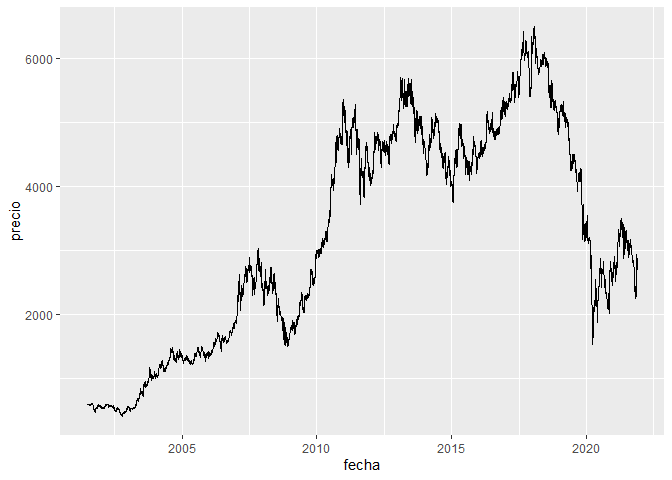

```r
ggplot(d) +
  geom_line(aes(fecha, precio))
```

```r
lista_empresas <- c("NUEVAPOLAR", "SMU", "BESALCO", "COPEC", "FALABELLA",
                    "BSANTANDER",  "CMPC", "CHILE", "SQM-B", "ENELAM", "CENCOSUD",
                    "BCI", "LTM",  "ENELCHILE", "SM-CHILE B", "CCU", "PARAUCO",
                    "ITAUCORP", "AGUAS-A",  "COLBUN", "ENTEL", "ECL", "CONCHATORO",
                    "RIPLEY", "AESGENER",  "ANDINA-B", "SONDA", "CAP", "ILC",
                    "SALFACORP", "SECURITY", "VAPORES",  "ENELGXCH", "ANTARCHILE",
                    "BANMEDICA", "EMBONOR-B", "FORUS",  "IAM", "MASISA", "ORO BLANCO",
                    "SK", "SMSAAM")
```

#### Evaluación

El objetivo es construir una aplicación que permita al usuario observar en un gráfico la variación del indicador de la empresa seleccionada a través del tiempo.

Usando el código descrito desarrollar una Shiny Web App que pose las siguientes características:

- (1 pto.) Disponga la información a través de un layout de *sidebar* y *mainpanel*.
- (1 pto.) Posea un input de tipo *select* para escoger un elemento de `lista_empresas` y otro input *range slider* con el fin de seleccionar años a analizar/graficar (0.5 cada input).
- (1 pto.) Incorporar un diseño con el paquete {shinythemes}.
- (2 pto.) La aplicación debe considerar salidas/outpus para un gráfico para los datos históricos y la tabla resumida por años (1 pto cada una).
- (1 pto.) Compartir la aplicación a través del servicio shinyapps.

#### Entrega

El formato de entrega es enviar el script desarrollado y el link de la página de shinyapps.io a través del buzón de tareas de Moodle.

#### Fechas de inicio/entrega

En la siguiente tabla se encuentran las diferentes fechas de entrega de la evaluación de Shiny según sección:

| Sección | Fecha Inicio | Fecha Entrega |
| --- | --- | --- |
| **Johnson** | Lunes 13 de Diciembre | Miércoles 22 de Diciembre |
| **Gauss** | Lunes 29 de Noviembre | Miércoles 8 de Diciembre |
| **Vaughan** | Viernes 26 de Noviembre | Domingo 5 de Noviembre |
| **Turing** | Lunes 29 de Noviembre | Miércoles 8 de Diciembre |
| **Jackson** | Jueves 18 de Noviembre | Domingo 28 de Noviembre |